[figure not shown]

# UFCFFY-15-M Cyber Security Analytics

# Assignment: Task 1

### Prepare by S M Aminur Rahman Student ID: 21042701

The completion of **Portfolio Task 1: Conduct an investigation on a web application to identify malicious attack activity using Python data science libraries** is worth **20%** towards your portfolio for the UFCFFY-15-M Cyber Security Analytics (CSA) module. Please refer to your Assignment Overview for full details.

### Portfolio Task 1: Conduct an investigation on a web application to identify malicious attack activity using Python data science libraries (20%)

For this task, you will be provided with a *personalised* dataset that you are expected to analyse. You should aim to identify any suspicious activities that have occurred in the dataset, based on your knowledge and understanding of web application security. You will need to ensure that your submission is made based on the information in your assigned dataset - **failure to use the dataset assigned to your username will result in a zero grade**. Your portfolio submission for this task should be an HTML export of your IPYNB Jupyter notebook that details your investigation using appropriate code cells to perform the required analysis and Markdown cells to explain your work.

As a cyber security analyst, you have been provided with a set of logs related to your organisation web server. You will need to analyse these logs and seek out suspicious activity based on the data available.

More information about Microsoft Internet Information Services (IIS) can be found at the following URL: https://docs.microsoft.com/en-us/previous-versions/iis/6.0-sdk/ms525410(v=vs.90)

**Dataset**: Please see the folder *"Portfolio Assignment"* under the Assignment tab on Blackboard for further detail related to the access and download of the necessary dataset.

**Hint:** The [TryHackMe room "HTTP in detail"](https://tryhackme.com/room/httpindetail) may help your research for what to investigate within this large dataset.

### Assessment and Marking

| Criteria | 0-39 | 40-49 | 50-59 | 60-69 | 70-84 | 85-100 |
| --- | --- | --- | --- | --- | --- | --- |
| **Identification of the suspicious activity (25%)** | No evidence of progress | A limited attempt to address this criteria | Some correct detail is identified but perhaps not all | Most correct detail is identified | All correct detail identified with good justification | All correct detail identified with excellent justification |
| **Analytical reasoning and process (25%)** | No evidence of progress | A limited attempt to address this criteria | Some evidence of analysis but perhaps some flaws in the approach | Evidence of analysis with only some minor flaws | Very good analytical approach | Excellent analytical approach |
| **Python and Pandas proficiency (25%)** | No evidence of progress | A limited attempt to address this criteria | Some fair usage but perhaps not optimal | Good usage of Python and Pandas with only minor flaws | Very good usage of in-built functions | Excellent professional usage of in-built functions |
| **Clarity and professional report presentation (25%)** | No evidence of progress | A limited attempt to address this criteria | Some evidence of markdown commentary but with major flaws | Markdown commentary with only minor flaws | Very good detail in markdown commentary | Excellent detail in markdown commentary |

To achieve the higher end of the grade scale, you need to demonstrate how you have conducted your investigating, identifying the malicious activity, and demonstrate a good command of Pandas data analysis to conduct your investigation.

### Submission Documents

Your submission for this task should include:

- **1 Jupyter Notebook exported in HTML format**. You should complete your work using the iPYNB file provided (i.e., this document). You should also complete the self-assessment section (below). Once you have completed your work, you should use the export function in Jupyter to save your notebook as an HTML document. *Do not submit a ipynb file - we will not execute any code during marking. Therefore, you must ensure that all cell output is clear in your HTML document for your marker.*

Your portfolio should be submitted to Blackboard by **14:00 on 12th May 2022**. This should should be a ZIP file that contains four documents:

- *Task1.html* (an HTML document exported from Jupyter notebook)
- *Task2.html* (an HTML document exported from Jupyter notebook)
- *Task3.pdf* (a PDF report of your research investigation)
- *Task4.txt* (a text file that contains instructions for accessing your video)

### Self-Assessment

For each criteria, please reflect on the marking rubric and indicate what grade you would expect to receive for the work that you are submitting. For your own personal development and learning, it is important to reflect on your work and to attempt to assess this careful. Do think carefully about both positive aspects of your work, as well as any limitations you may have faced.

- **Identification of the suspicious activity (25%)**:  
  You estimate that your grade will be ___20.

  > The suspicious activity with three different IP address from my assigned data set. Along with my analytical ability including error code analysis and time of attack.
- **Analytical reasoning and rationale (25%)**:  
  You estimate that your grade will be ___20.

  > With the help of class lecture, lab sheet and my understanding I gain the knowledge to solve the problem.
- **Python and Pandas proficiency (25%)**:  
  You estimate that your grade will be ____20.

  > This is a very new language I start working with this tearm and try to learn as much as I can. In Python and Panda, I try to learn to have a clear view to implement in my given task.
- **Clarity and professional report presentation (25%)**:  
  You estimate that your grade will be ___20.

  > This is very new as I said, I try to implement as much markdown possible.

### Contact

Questions about this assignment should be directed to your module leader (Phil.Legg@uwe.ac.uk). You should use the [online Q&A form](https://forms.office.com/r/cB8iDH5BXf) to ask questions related to this module and this assignment, as well as utilising the on-site teaching sessions.

```python
# Import libraries as required
import pandas as pd
import numpy as np
import matplotlib.pyplot as plt
import warnings
warnings.filterwarnings("ignore")
pd.set_option('display.max_rows', 10)
```

In the cell below, you will need to change `data_file` to your own specific data filename. The example data file is purely to demonstrate some initial steps for your investigation and should not be used.

## I use my own data set which is assigned for my analysis named "s33-rahman"

```python
data_file = 's33-rahman'
```

```python
# Load in the data set as required -
data_path = './'
data = pd.read_csv(data_path + data_file, delim_whitespace=True)
data.to_csv('out.csv')
temp_df = data[data.columns[:-1]]
temp_df.columns = data.columns[1:]
data = temp_df
data
```

|  | date | time | s-ip | cs-method | cs-uri-stem | cs-uri-query | s-port | cs-username | c-ip | cs(User-Agent) | cs(Referer) | sc-status | sc-substatus | sc-win32-status | time-taken |
| --- | --- | --- | --- | --- | --- | --- | --- | --- | --- | --- | --- | --- | --- | --- | --- |
| 0 | 2022-01-01 | 02:15:00 | 44.182.28.121 | GET | bujzfrbw.css | - | 443 | - | 194.9.33.182 | Mozilla/5.0+(Windows+NT+10.0;+Win64;+x64)+Appl... | - | 404 | 0 | 0 | 21 |
| 1 | 2022-01-01 | 02:15:00 | 44.182.28.121 | GET | index.aspx | - | 443 | - | 194.9.33.182 | Mozilla/5.0+(Windows+NT+10.0;+Win64;+x64)+Appl... | - | 200 | 0 | 0 | 29 |
| 2 | 2022-01-01 | 02:15:24 | 44.182.28.121 | GET | main.css | - | 443 | - | 194.9.33.182 | Mozilla/5.0+(Windows+NT+10.0;+Win64;+x64)+Appl... | https://bankofpunk.local/index.aspx | 200 | 0 | 0 | 28 |
| 3 | 2022-01-01 | 02:15:24 | 44.182.28.121 | GET | lrmotihn.css | - | 443 | - | 194.9.33.182 | Mozilla/5.0+(Windows+NT+10.0;+Win64;+x64)+Appl... | https://bankofpunk.local/index.aspx | 404 | 0 | 0 | 20 |
| 4 | 2022-01-01 | 02:15:24 | 44.182.28.121 | GET | index.aspx | - | 443 | - | 194.9.33.182 | Mozilla/5.0+(Windows+NT+10.0;+Win64;+x64)+Appl... | https://bankofpunk.local/index.aspx | 200 | 0 | 0 | 23 |
| ... | ... | ... | ... | ... | ... | ... | ... | ... | ... | ... | ... | ... | ... | ... | ... |
| 70253 | 2022-01-30 | 23:52:56 | 44.182.28.121 | GET | footer.css | - | 443 | ju740580 | 37.230.58.201 | Mozilla/5.0+(iPhone;+CPU+iPhone+OS+10_2_1+like... | https://bankofpunk.local/transactions.aspx | 200 | 0 | 0 | 30 |
| 70254 | 2022-01-30 | 23:52:56 | 44.182.28.121 | GET | nguuehae.js | v=277022 | 443 | ju740580 | 37.230.58.201 | Mozilla/5.0+(iPhone;+CPU+iPhone+OS+10_2_1+like... | https://bankofpunk.local/transactions.aspx | 200 | 0 | 0 | 28 |
| 70255 | 2022-01-30 | 23:52:56 | 44.182.28.121 | GET | transactions.aspx | page=6 | 443 | ju740580 | 37.230.58.201 | Mozilla/5.0+(iPhone;+CPU+iPhone+OS+10_2_1+like... | https://bankofpunk.local/transactions.aspx | 200 | 0 | 0 | 28 |
| 70256 | 2022-01-30 | 23:53:23 | 44.182.28.121 | GET | main.css | - | 443 | - | 37.230.58.201 | Mozilla/5.0+(iPhone;+CPU+iPhone+OS+10_2_1+like... | https://bankofpunk.local/transactions.aspx | 200 | 0 | 0 | 23 |
| 70257 | 2022-01-30 | 23:53:23 | 44.182.28.121 | GET | logout.aspx | - | 443 | - | 37.230.58.201 | Mozilla/5.0+(iPhone;+CPU+iPhone+OS+10_2_1+like... | https://bankofpunk.local/transactions.aspx | 301 | 0 | 0 | 26 |

70258 rows × 15 columns

```python
# Search for all unique entries in 'cs(Referer)'
data['cs(Referer)'].unique()
```

```
array(['-', 'https://bankofpunk.local/index.aspx',
       'https://bankofpunk.local/login.aspx',
       'https://bankofpunk.local/account_status.aspx',
       'https://bankofpunk.local/transactions.aspx',
       'https://bankofpunk.local/transfer.aspx',
       'https://bankofpunk.local/transfer_complete.aspx',
       'https://bankofpunk.local/faq.aspx',
       'https://bankofpunk.local/change_avatar.aspx',
       'https://bankofpunk.local/changepassword.aspx'], dtype=object)
```

```python
# Get count of each unique value for 'cs(Referer)'
data['cs(Referer)'].value_counts()
```

```
https://bankofpunk.local/transactions.aspx         23077
https://bankofpunk.local/index.aspx                18092
https://bankofpunk.local/login.aspx                13917
https://bankofpunk.local/account_status.aspx        6206
-                                                   6058
https://bankofpunk.local/transfer.aspx              1557
https://bankofpunk.local/changepassword.aspx         566
https://bankofpunk.local/faq.aspx                    368
https://bankofpunk.local/transfer_complete.aspx      314
https://bankofpunk.local/change_avatar.aspx          103
Name: cs(Referer), dtype: int64
```

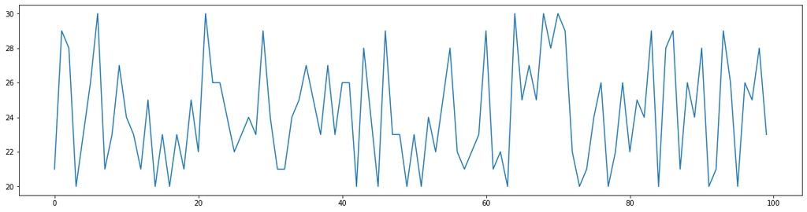

```python
# Plot the first 100 values for the 'time-taken' column
plt.figure(figsize=(20,5))
plt.plot(data['time-taken'][:100])
plt.show()
```

# Start your investigation...

Carry on with the investigation based on the initial code provided above. Conclude you investigation with a summary of what activities you have identified and why they are deemed to be suspicious.

## Step-1: My Investigation

Based on my knowledge and understanding of web application security, first I get all the status code from the dataset. As because with this status, I can identify malicious activity. From below we use the command, by which I can collect all the list of code with how many times the IP appear whit the help of value counts.

```python
data['sc-status'].value_counts()
```

```
200    58789
404     5815
301     4631
401     1023
Name: sc-status, dtype: int64
```

## Step-2: Meaning of each error code

### From above list, i get only 4 error code and from this error code, I find below explananion for each code,

- Error code 200 = The request was received and understood and is being processed.
- Error code 404 = The page you were trying to reach on a website couldn't be found on their server
- Error code 301 = Moved Permanently is used for permanent redirecting.
- Error code 401 = The client request has not been completed because it lacks valid authentication credentials for the requested resource.

Above explanation of the codes, I understand that only one code explained the user who trying to access to the server is not the real user and who do not know the credentials. If the user knows the credential, then there will not be generated such code more than thousands time. Again, if the user is real and sometimes mistakenly input the wrong credential (which is natural) the error code would generates more than thousands time which is suspicious. So, I start investigate with this error code 401. Below is the command to collect all the information related to 401 codes.  
Note that rest of the error code 404 and 301 are hits by more than four thousand times but the error explanation shows that wrong web address or redirecting accordingly. About error code 200 is for successful action. So, i continue with error code 401.

```python
data_401 = data[data['sc-status']==401]

data_401
```

|  | date | time | s-ip | cs-method | cs-uri-stem | cs-uri-query | s-port | cs-username | c-ip | cs(User-Agent) | cs(Referer) | sc-status | sc-substatus | sc-win32-status | time-taken |
| --- | --- | --- | --- | --- | --- | --- | --- | --- | --- | --- | --- | --- | --- | --- | --- |
| 259 | 2022-01-01 | 08:26:22 | 44.182.28.121 | POST | login.aspx | - | 443 | - | 178.130.142.168 | Mozilla/5.0+(Windows+NT+10.0;+WOW64;+Trident/7... | https://bankofpunk.local/index.aspx | 401 | 0 | 0 | 28 |
| 260 | 2022-01-01 | 08:26:25 | 44.182.28.121 | POST | login.aspx | - | 443 | - | 178.130.142.168 | Mozilla/5.0+(Windows+NT+10.0;+WOW64;+Trident/7... | https://bankofpunk.local/login.aspx | 401 | 0 | 0 | 26 |
| 261 | 2022-01-01 | 08:26:26 | 44.182.28.121 | POST | login.aspx | - | 443 | - | 178.130.142.168 | Mozilla/5.0+(Windows+NT+10.0;+WOW64;+Trident/7... | https://bankofpunk.local/login.aspx | 401 | 0 | 0 | 22 |
| 262 | 2022-01-01 | 08:26:28 | 44.182.28.121 | POST | login.aspx | - | 443 | - | 178.130.142.168 | Mozilla/5.0+(Windows+NT+10.0;+WOW64;+Trident/7... | https://bankofpunk.local/login.aspx | 401 | 0 | 0 | 21 |
| 263 | 2022-01-01 | 08:26:29 | 44.182.28.121 | POST | login.aspx | - | 443 | - | 178.130.142.168 | Mozilla/5.0+(Windows+NT+10.0;+WOW64;+Trident/7... | https://bankofpunk.local/login.aspx | 401 | 0 | 0 | 26 |
| ... | ... | ... | ... | ... | ... | ... | ... | ... | ... | ... | ... | ... | ... | ... | ... |
| 69733 | 2022-01-30 | 19:44:43 | 44.182.28.121 | POST | login.aspx | - | 443 | - | 185.254.19.201 | Mozilla/5.0+(Windows+NT+10.0;+Win64;+x64)+Appl... | https://bankofpunk.local/index.aspx | 401 | 0 | 0 | 28 |
| 69735 | 2022-01-30 | 19:44:47 | 44.182.28.121 | POST | login.aspx | - | 443 | - | 185.254.19.201 | Mozilla/5.0+(Windows+NT+10.0;+Win64;+x64)+Appl... | https://bankofpunk.local/login.aspx | 401 | 0 | 0 | 20 |
| 69739 | 2022-01-30 | 19:45:08 | 44.182.28.121 | POST | login.aspx | - | 443 | - | 185.254.19.201 | Mozilla/5.0+(Windows+NT+10.0;+Win64;+x64)+Appl... | https://bankofpunk.local/login.aspx | 401 | 0 | 0 | 26 |
| 70012 | 2022-01-30 | 21:18:38 | 44.182.28.121 | POST | login.aspx | - | 443 | - | 137.222.52.32 | Mozilla/4.0+(compatible;+MSIE+6.0;+Windows+NT+... | https://bankofpunk.local/index.aspx | 401 | 0 | 0 | 27 |
| 70150 | 2022-01-30 | 22:29:41 | 44.182.28.121 | POST | login.aspx | - | 443 | - | 23.4.218.22 | Mozilla/5.0+(Windows+NT+10.0;+WOW64;+Trident/7... | https://bankofpunk.local/index.aspx | 401 | 0 | 0 | 23 |

1023 rows × 15 columns

## Step-3: Convert time

### Here we use conversion to get the total minute.

```python
data_401['total_time'] = pd.to_datetime(data_401['time'])
# data_401['total_minutes'] = data_401['total_time'].dt.minute
data_401['hit_time'] = ((data_401['total_time'].dt.hour * 100) + data_401['total_time'].dt.minute)
data_401
```

|  | date | time | s-ip | cs-method | cs-uri-stem | cs-uri-query | s-port | cs-username | c-ip | cs(User-Agent) | cs(Referer) | sc-status | sc-substatus | sc-win32-status | time-taken | total_time | hit_time |
| --- | --- | --- | --- | --- | --- | --- | --- | --- | --- | --- | --- | --- | --- | --- | --- | --- | --- |
| 259 | 2022-01-01 | 08:26:22 | 44.182.28.121 | POST | login.aspx | - | 443 | - | 178.130.142.168 | Mozilla/5.0+(Windows+NT+10.0;+WOW64;+Trident/7... | https://bankofpunk.local/index.aspx | 401 | 0 | 0 | 28 | 2022-05-14 08:26:22 | 826 |
| 260 | 2022-01-01 | 08:26:25 | 44.182.28.121 | POST | login.aspx | - | 443 | - | 178.130.142.168 | Mozilla/5.0+(Windows+NT+10.0;+WOW64;+Trident/7... | https://bankofpunk.local/login.aspx | 401 | 0 | 0 | 26 | 2022-05-14 08:26:25 | 826 |
| 261 | 2022-01-01 | 08:26:26 | 44.182.28.121 | POST | login.aspx | - | 443 | - | 178.130.142.168 | Mozilla/5.0+(Windows+NT+10.0;+WOW64;+Trident/7... | https://bankofpunk.local/login.aspx | 401 | 0 | 0 | 22 | 2022-05-14 08:26:26 | 826 |
| 262 | 2022-01-01 | 08:26:28 | 44.182.28.121 | POST | login.aspx | - | 443 | - | 178.130.142.168 | Mozilla/5.0+(Windows+NT+10.0;+WOW64;+Trident/7... | https://bankofpunk.local/login.aspx | 401 | 0 | 0 | 21 | 2022-05-14 08:26:28 | 826 |
| 263 | 2022-01-01 | 08:26:29 | 44.182.28.121 | POST | login.aspx | - | 443 | - | 178.130.142.168 | Mozilla/5.0+(Windows+NT+10.0;+WOW64;+Trident/7... | https://bankofpunk.local/login.aspx | 401 | 0 | 0 | 26 | 2022-05-14 08:26:29 | 826 |
| ... | ... | ... | ... | ... | ... | ... | ... | ... | ... | ... | ... | ... | ... | ... | ... | ... | ... |
| 69733 | 2022-01-30 | 19:44:43 | 44.182.28.121 | POST | login.aspx | - | 443 | - | 185.254.19.201 | Mozilla/5.0+(Windows+NT+10.0;+Win64;+x64)+Appl... | https://bankofpunk.local/index.aspx | 401 | 0 | 0 | 28 | 2022-05-14 19:44:43 | 1944 |
| 69735 | 2022-01-30 | 19:44:47 | 44.182.28.121 | POST | login.aspx | - | 443 | - | 185.254.19.201 | Mozilla/5.0+(Windows+NT+10.0;+Win64;+x64)+Appl... | https://bankofpunk.local/login.aspx | 401 | 0 | 0 | 20 | 2022-05-14 19:44:47 | 1944 |
| 69739 | 2022-01-30 | 19:45:08 | 44.182.28.121 | POST | login.aspx | - | 443 | - | 185.254.19.201 | Mozilla/5.0+(Windows+NT+10.0;+Win64;+x64)+Appl... | https://bankofpunk.local/login.aspx | 401 | 0 | 0 | 26 | 2022-05-14 19:45:08 | 1945 |
| 70012 | 2022-01-30 | 21:18:38 | 44.182.28.121 | POST | login.aspx | - | 443 | - | 137.222.52.32 | Mozilla/4.0+(compatible;+MSIE+6.0;+Windows+NT+... | https://bankofpunk.local/index.aspx | 401 | 0 | 0 | 27 | 2022-05-14 21:18:38 | 2118 |
| 70150 | 2022-01-30 | 22:29:41 | 44.182.28.121 | POST | login.aspx | - | 443 | - | 23.4.218.22 | Mozilla/5.0+(Windows+NT+10.0;+WOW64;+Trident/7... | https://bankofpunk.local/index.aspx | 401 | 0 | 0 | 23 | 2022-05-14 22:29:41 | 2229 |

1023 rows × 17 columns

## Next Step

### After having all the row associate with error code 401, we are going to save this separate information to a file named 'out_401.csv'.

#### (Note: It is not mandatory but for clear view of self-understanding, I make the subset of the original dataset.)

## File saved with name "out_401.csv"

```python
data_401.to_csv('out_401.csv')
```

## Now following two command is for reading the subset and display the information

```python
data_401=pd.read_csv('./out_401.csv')
```

```python
data_401
```

|  | Unnamed: 0 | date | time | s-ip | cs-method | cs-uri-stem | cs-uri-query | s-port | cs-username | c-ip | cs(User-Agent) | cs(Referer) | sc-status | sc-substatus | sc-win32-status | time-taken | total_time | hit_time |
| --- | --- | --- | --- | --- | --- | --- | --- | --- | --- | --- | --- | --- | --- | --- | --- | --- | --- | --- |
| 0 | 259 | 2022-01-01 | 08:26:22 | 44.182.28.121 | POST | login.aspx | - | 443 | - | 178.130.142.168 | Mozilla/5.0+(Windows+NT+10.0;+WOW64;+Trident/7... | https://bankofpunk.local/index.aspx | 401 | 0 | 0 | 28 | 2022-05-14 08:26:22 | 826 |
| 1 | 260 | 2022-01-01 | 08:26:25 | 44.182.28.121 | POST | login.aspx | - | 443 | - | 178.130.142.168 | Mozilla/5.0+(Windows+NT+10.0;+WOW64;+Trident/7... | https://bankofpunk.local/login.aspx | 401 | 0 | 0 | 26 | 2022-05-14 08:26:25 | 826 |
| 2 | 261 | 2022-01-01 | 08:26:26 | 44.182.28.121 | POST | login.aspx | - | 443 | - | 178.130.142.168 | Mozilla/5.0+(Windows+NT+10.0;+WOW64;+Trident/7... | https://bankofpunk.local/login.aspx | 401 | 0 | 0 | 22 | 2022-05-14 08:26:26 | 826 |
| 3 | 262 | 2022-01-01 | 08:26:28 | 44.182.28.121 | POST | login.aspx | - | 443 | - | 178.130.142.168 | Mozilla/5.0+(Windows+NT+10.0;+WOW64;+Trident/7... | https://bankofpunk.local/login.aspx | 401 | 0 | 0 | 21 | 2022-05-14 08:26:28 | 826 |
| 4 | 263 | 2022-01-01 | 08:26:29 | 44.182.28.121 | POST | login.aspx | - | 443 | - | 178.130.142.168 | Mozilla/5.0+(Windows+NT+10.0;+WOW64;+Trident/7... | https://bankofpunk.local/login.aspx | 401 | 0 | 0 | 26 | 2022-05-14 08:26:29 | 826 |
| ... | ... | ... | ... | ... | ... | ... | ... | ... | ... | ... | ... | ... | ... | ... | ... | ... | ... | ... |
| 1018 | 69733 | 2022-01-30 | 19:44:43 | 44.182.28.121 | POST | login.aspx | - | 443 | - | 185.254.19.201 | Mozilla/5.0+(Windows+NT+10.0;+Win64;+x64)+Appl... | https://bankofpunk.local/index.aspx | 401 | 0 | 0 | 28 | 2022-05-14 19:44:43 | 1944 |
| 1019 | 69735 | 2022-01-30 | 19:44:47 | 44.182.28.121 | POST | login.aspx | - | 443 | - | 185.254.19.201 | Mozilla/5.0+(Windows+NT+10.0;+Win64;+x64)+Appl... | https://bankofpunk.local/login.aspx | 401 | 0 | 0 | 20 | 2022-05-14 19:44:47 | 1944 |
| 1020 | 69739 | 2022-01-30 | 19:45:08 | 44.182.28.121 | POST | login.aspx | - | 443 | - | 185.254.19.201 | Mozilla/5.0+(Windows+NT+10.0;+Win64;+x64)+Appl... | https://bankofpunk.local/login.aspx | 401 | 0 | 0 | 26 | 2022-05-14 19:45:08 | 1945 |
| 1021 | 70012 | 2022-01-30 | 21:18:38 | 44.182.28.121 | POST | login.aspx | - | 443 | - | 137.222.52.32 | Mozilla/4.0+(compatible;+MSIE+6.0;+Windows+NT+... | https://bankofpunk.local/index.aspx | 401 | 0 | 0 | 27 | 2022-05-14 21:18:38 | 2118 |
| 1022 | 70150 | 2022-01-30 | 22:29:41 | 44.182.28.121 | POST | login.aspx | - | 443 | - | 23.4.218.22 | Mozilla/5.0+(Windows+NT+10.0;+WOW64;+Trident/7... | https://bankofpunk.local/index.aspx | 401 | 0 | 0 | 23 | 2022-05-14 22:29:41 | 2229 |

1023 rows × 18 columns

## Examin the subset

We can now see the smaller data set which we need to concentrate more to finding our objective.

```python
data_401.iloc[:,[3,4,6,7,8,9,12,15,17]]
```

|  | s-ip | cs-method | cs-uri-query | s-port | cs-username | c-ip | sc-status | time-taken | hit_time |
| --- | --- | --- | --- | --- | --- | --- | --- | --- | --- |
| 0 | 44.182.28.121 | POST | - | 443 | - | 178.130.142.168 | 401 | 28 | 826 |
| 1 | 44.182.28.121 | POST | - | 443 | - | 178.130.142.168 | 401 | 26 | 826 |
| 2 | 44.182.28.121 | POST | - | 443 | - | 178.130.142.168 | 401 | 22 | 826 |
| 3 | 44.182.28.121 | POST | - | 443 | - | 178.130.142.168 | 401 | 21 | 826 |
| 4 | 44.182.28.121 | POST | - | 443 | - | 178.130.142.168 | 401 | 26 | 826 |
| ... | ... | ... | ... | ... | ... | ... | ... | ... | ... |
| 1018 | 44.182.28.121 | POST | - | 443 | - | 185.254.19.201 | 401 | 28 | 1944 |
| 1019 | 44.182.28.121 | POST | - | 443 | - | 185.254.19.201 | 401 | 20 | 1944 |
| 1020 | 44.182.28.121 | POST | - | 443 | - | 185.254.19.201 | 401 | 26 | 1945 |
| 1021 | 44.182.28.121 | POST | - | 443 | - | 137.222.52.32 | 401 | 27 | 2118 |
| 1022 | 44.182.28.121 | POST | - | 443 | - | 23.4.218.22 | 401 | 23 | 2229 |

1023 rows × 9 columns

## Individual IP Value Counts

When we are counting value for this error code "401" associate with customer IP thats is "c-ip", that means we are going to count how many times which IP is going to hit to the link. Using "value_counts" command we get list of IP address and how many times it appears.

**Note That - We are going to name the "data_401" to "data_IP" as it is associate with IP now.**

```python
data_IP=data_401['c-ip'].value_counts()
data_IP
```

```
185.242.182.82     281
185.87.132.173     246
178.130.142.168     65
213.39.9.174         6
91.199.181.226       6
                  ...
185.125.85.226       1
195.137.176.11       1
104.238.173.131      1
45.250.25.165        1
23.4.218.22          1
Name: c-ip, Length: 200, dtype: int64
```

## Top Five counts.

**We can get the top five counts displayed by using folowing command from data_IP.**

```python
data_IP.head()
```

```
185.242.182.82     281
185.87.132.173     246
178.130.142.168     65
213.39.9.174         6
91.199.181.226       6
Name: c-ip, dtype: int64
```

## Display data in Pie chart

**Below command is running to implement the following table on a graphical view for more understanding. I find more visual understanding when we look on pie chart.**

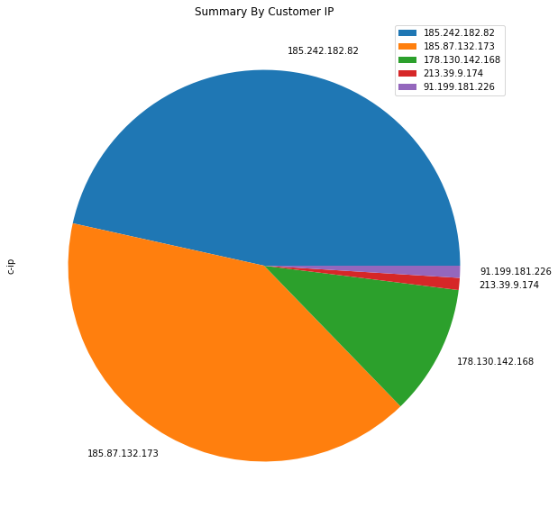

```python
#SC_Status value count most uses 10 entry
c_ip = pd.value_counts(data_401['c-ip'])
# reduce chart junk
plt.axes(frameon=0)
c_ip[:5].plot(kind='pie', rot=0, title="Summary By Customer IP", figsize=(20,10)).grid(False)

plt.legend()
plt.show()
```

## Analysis from Pie chart

**We can easily understand that the most area is covered by blue color then orange and lastly the 3rd most cover area is green**

- Blue Colour Belongs to IP: 185.242.182.82 - which got 281 time the error code 401
- Orange Colour Belongs to IP: 185.87.132.173 - which got 246 time the error code 401
- Green Colour Belongs to IP: 178.130.142.168 - which got 65 time the error code 401

## Analysis individual IP with Time

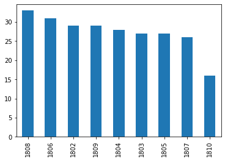

```python
data_ip_highfailed = data_401[data_401['c-ip'] == '185.87.132.173']
data_ip_highfailed['hit_time'].value_counts()[:25].plot(kind='bar');
```

## Analysis individual IP with Time

### The most attack IP is 185.242.182.82 and this IP hit the server with below time.

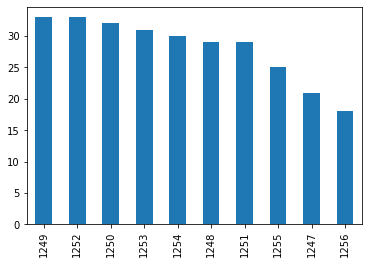

```python
data_ip_highfailed = data_401[data_401['c-ip'] == '185.242.182.82']
data_ip_highfailed['hit_time'].value_counts()[:25].plot(kind='bar');
```

## Analysis individual IP with Time

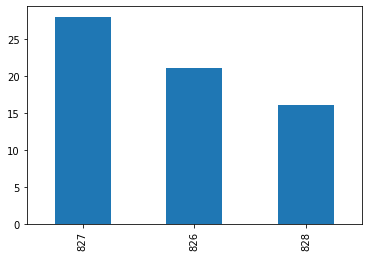

```python
data_ip_highfailed = data_401[data_401['c-ip'] == '178.130.142.168']
data_ip_highfailed['hit_time'].value_counts()[:25].plot(kind='bar');
```

## Conclusion

In Conclusion, we can conclude that most of the malicious attack was coming from the IP address that is **185.242.182.82** and the count is **281**, means this IP address try to communicate with the server **281** times and made unsuccessful. Rest two more IP address is also is in similar activities, those are **185.87.132.173** which hit the server **246** times and **178.130.142.168** hit **65** times.